# Taller 3

Santiago Aillón, Santiago Arévalo, Juan José Caballero y Laura Ortiz

2022-09-01

### *1.* Un investigador considera tres iındices para medir la severidad de los ataques alcorazon. Los valores de esos ́ındices para n = 40 pacientes con ataque al corazon que llegan a las emergencias de un hospital producen las siguientes estadiısticas resumidas

#### *a.* Los tres indices son evaluados para cada paciente. Realice una prueba para la igualdad de las medias de los indices con α = 0.05

$T^2 = n \bar{\mathbb{X}}c^t(cSc^t)^{-1}c\bar{\mathbb{X}}$

```r
X = (c(46.1, 57.3, 50.4))
S = cbind(c(101.3, 63.0, 71.0), c(63.0, 80.2, 55.6), c(71.0, 55.6, 97.4))
C = rbind(c(1, -1, 0), c(1, 0 ,-1))
Ct = t(C)
n = 40
q = 3

csc = solve(C%*%S%*%Ct)

t = n%*%X%*%Ct%*%csc%*%C%*%X
t
```

```
##          [,1]
## [1,] 90.49458
```

```r
f = qf(1-0.05,df1=q-1,df2=n-q+1)

d = (n-1)*(q-1)/(n-q+1)

Ft = d*f
Ft
```

```
## [1] 6.660417
```

Como $T^2 = 90.49458 > 6.660417 = \frac{(n-1)(q-1)}{(n-q+1)} * F_{q-1,n-q+1}$ rechazamos $H_0$

#### *b.* Juzgue las diferencias entre pares de las medias de los ındices usando intervalos de confianza ($T^2$) simultaneos del 95%

$C^t \bar{\mathbb{X}} \pm \sqrt{\frac{(n-1)(q-1)}{(n-q+1)} * F_{q-1,n-q+1}(\alpha)} \sqrt{\frac{CSC^t}{n}}$

```r
n = 40
q = 3
X = (c(46.1, 57.3, 50.4))
S = cbind(c(101.3, 63.0, 71.0), c(63.0, 80.2, 55.6), c(71.0, 55.6, 97.4))
C1_2 = c(1, -1, 0)
f = qf(1-0.05,df1=q-1,df2=n-q+1)

int1_iz = C1_2 %*% X - sqrt( ((n-1)*(q-1)/(n-q-1)) * f) * sqrt( C1_2%*%S%*%C1_2/n )
int1_iz
```

```
##           [,1]
## [1,] -14.32326
```

```r
int1_de = C1_2 %*% X + sqrt( ((n-1)*(q-1)/(n-q-1)) * f) * sqrt( C1_2%*%S%*%C1_2/n )
int1_de
```

```
##           [,1]
## [1,] -8.076743
```

$-14.32326 \le \bar{\mathbb{X}}_{1-2} \le -8.076743$

```r
C1_3 = c(1, 0 ,-1)

int1_iz = C1_3 %*% X - sqrt( ((n-1)*(q-1)/(n-q-1)) * f) * sqrt( C1_3%*%S%*%C1_3/n )
int1_iz
```

```
##           [,1]
## [1,] -7.456842
```

```r
int1_de = C1_3 %*% X + sqrt( ((n-1)*(q-1)/(n-q-1)) * f) * sqrt( C1_3%*%S%*%C1_3/n )
int1_de
```

```
##           [,1]
## [1,] -1.143158
```

### *2.* Observaciones sobre dos respuestas fueron coleccionadas para dos tratamientos. Las observaciones vectoriales $[x_1, x_2]'$ fueron:

$$\textbf{Tratamiento 2}= \left[\begin{array}{cc}
3\\
3
\end{array}\right],
\left[\begin{array}{cc}
1\\
6
\end{array}\right],
\left[\begin{array}{cc}
2\\
3
\end{array}\right]$$
$$\textbf{Tratamiento 3}= \left[\begin{array}{cc}
2\\
3
\end{array}\right],
\left[\begin{array}{cc}
5\\
1
\end{array}\right],
\left[\begin{array}{cc}
3\\
1
\end{array}\right],
\left[\begin{array}{cc}
2\\
3
\end{array}\right]$$

#### *a.* Calcule Spooled.

```r
tratamiento2 = cbind(rbind(3,3), rbind(1,6), rbind(2,3))
tratamiento3 = cbind(rbind(2,3), rbind(5,1), rbind(3,1), rbind(2,3))

tratamiento2
```

```
##      [,1] [,2] [,3]
## [1,]    3    1    2
## [2,]    3    6    3
```

```r
tratamiento3
```

```
##      [,1] [,2] [,3] [,4]
## [1,]    2    5    3    2
## [2,]    3    1    1    3
```

```r
n2 = 3 # Tratamiento 2
n3 = 4 # Tratamiento 3
p = 2

S2 = cov(t(tratamiento2))
S2
```

```
##      [,1] [,2]
## [1,]  1.0 -1.5
## [2,] -1.5  3.0
```

```r
S3 = cov(t(tratamiento3))
S3
```

```
##           [,1]      [,2]
## [1,]  2.000000 -1.333333
## [2,] -1.333333  1.333333
```

```r
Spooled = ((n2 - 1) / (n2 + n3 - 2)) * S2 + ((n3 - 1) / (n2 + n3 - 2)) * S3
Spooled
```

```
##      [,1] [,2]
## [1,]  1.6 -1.4
## [2,] -1.4  2.0
```

#### *b.* Realice la prueba $H_0 : \mu_{2} − \mu_{3} = 0$ usando un enfoque de dos muestras con $\alpha = .01$.

```r
x2_bar = (1 / n2) * (rbind(3,3) + rbind(1,6) + rbind(2,3))
x3_bar = (1 / n3) * (rbind(2,3) + rbind(5,1) + rbind(3,1) + rbind(2,3))

T2 = t(x2_bar - x3_bar) %*% solve(((1 / n2) + (1 / n3)) *Spooled) %*% (x2_bar - x3_bar)
T2
```

```
##          [,1]
## [1,] 3.870968
```

```r
C2 = ((n2 + n3 - 2)*p / (n2 + n3 - p - 1)) * qf(0.01, p, n2 + n3 - p - 1, lower.tail = FALSE)
C2
```

```
## [1] 45
```

```r
T2 > C2
```

```
##       [,1]
## [1,] FALSE
```

Se puede concluir que como $T^{2} < C^{2}$ no se recahza $H_0$.

#### *c.* Construya un intervalo de confianza simultáneo ($T^2$) del 99% para las diferencias $\mu_{2i} − \mu_{3i}$, $i = 1, 2$.

```r
for (x in 1:2){
lw_int = (x2_bar[x] - x3_bar[x] - sqrt((1/n2) + (1/n3)) * sqrt(Spooled[1, 1]))
up_int = (x2_bar[x] - x3_bar[x] + sqrt((1/n2) + (1/n3)) * sqrt(Spooled[2, 2]))

print(lw_int)
print(up_int)
}
```

```
## [1] -1.966092
## [1] 0.08012345
## [1] 1.033908
## [1] 3.080123
```

### *3.* Dados los datos

$$\begin{array}{ l|rrrrr }
Z_1 & 10 & 5 & 7 & 19 & 11 & 18 \\
Z_2 & 2 & 3 & 3 & 6 & 7 & 9 \\
\hline Y & 15 & 9 & 3 & 25 & 7 & 13 \\
\end{array}$$

#### *a.* Ajuste el modelo de regresion lineal

$$Y_j = \beta_0 + \beta_1 z_{j1} + \beta_2
z_{j2} + \epsilon_j$$
$$j= 1, 2, ...,
6$$

```r
Z_1 = c(10, 5, 7, 19, 11, 18)
Z_2 = c(2, 3, 3, 6, 7, 9)
Y = c (15, 9, 3, 25, 7, 13)

modelo <- lm(Y ~ Z_1 + Z_2)
summary(modelo)
```

```
##
## Call:
## lm(formula = Y ~ Z_1 + Z_2)
##
## Residuals:
##       1       2       3       4       5       6
## -0.5945  4.5054 -5.0592  2.1180  0.5649 -1.5347
##
## Coefficients:
##             Estimate Std. Error t value Pr(>|t|)
## (Intercept)   2.1480     4.2967   0.500   0.6515
## Z_1           1.7823     0.4982   3.578   0.0374 *
## Z_2          -2.1883     1.0329  -2.119   0.1243
## ---
## Signif. codes:  0 '***' 0.001 '**' 0.01 '*' 0.05 '.' 0.1 ' ' 1
##
## Residual standard error: 4.219 on 3 degrees of freedom
## Multiple R-squared:  0.8183, Adjusted R-squared:  0.6972
## F-statistic: 6.757 on 2 and 3 DF,  p-value: 0.07743
```

#### *b.* Determine los intervalos de confianza del 95% simultaneos (uno a la vez) para $\beta_1$ y $\beta_2$.

$\hat{\beta_i} \pm \sqrt{var{\hat{\beta_i}}}\sqrt{(r+1) F_{r+1, n-r-1}}$

```r
r = 2
n = 6
z0 <- rep(1,6)
z1 <- c(10,5,7,19,11,18)
z2 <- c( 2,3,3, 6, 7, 9)
Z <- cbind(z0,z1,z2)
B_1 = 1.7823
B_2 = -2.1883

err = rbind(-0.5945, 4.5054, -5.0592, 2.1180, 0.5649, -1.5347)
err_t = cbind(-0.5945, 4.5054, -5.0592, 2.1180, 0.5649, -1.5347)

S2 = ((err_t%*%err)/(n-r-1))
var_i = S2[,1] * (solve(t(Z) %*% Z))

f = qf(1 - 0.05, r+1, n - r - 1)

inter1_iz = 1.7823 - sqrt(var_i[2,2]) * sqrt( (r+1)*f)
inter1_de = 1.7823 + sqrt(var_i[2,2]) * sqrt( (r+1)*f)
inter2_iz = -2.1883 - sqrt(var_i[3,3]) * sqrt( (r+1)*f)
inter2_de = -2.1883 + sqrt(var_i[3,3]) * sqrt( (r+1)*f)
```

$$-0.8458689 \le \beta_1 \le
4.410469$$
$$-7.637075 \le
\beta_2 \le 3.260475$$

#### *d.* Determine el valor esperado de la prediccion $E((Y))$ para $z_1 = 6$ y $z_2 = 4$. Calcule su intervalo de confianza del $95%$ correspondiente (el del valor esperado).

```r
betas = rbind(2.1480, 1.7823, -2.1883)

z1 = 6
z2 = 4
Z_tem<- cbind(c(1,z1,z2))

E<-t( Z_tem )%*%betas
```

$E(Y) = 4.0886$

#### *e.* Determine el intervalo de confianza del $95%$ para la prediccion (Y ) cuando $z_1 = 6$ y $z_2 = 4$.

```r
Z
```

```
##      z0 z1 z2
## [1,]  1 10  2
## [2,]  1  5  3
## [3,]  1  7  3
## [4,]  1 19  6
## [5,]  1 11  7
## [6,]  1 18  9
```

```r
Z_tem
```

```
##      [,1]
## [1,]    1
## [2,]    6
## [3,]    4
```

```r
intervn_iz = f * sqrt( (t( Z_tem ) %*% solve( ( t( Z ) %*% Z ) ) %*% Z_tem ) %*% S2 )
intervn_iz
```

```
##          [,1]
## [1,] 25.63505
```

### *4.* La librería MASS contiene el dataset de Boston, el cual registró la variable medv (valor medio de una casa) para 506 barrios en Boston. En este ejercicio, se buscará predecir la variable medv usando 13 predictores tales como: rm (número promedio de habitaciones por casa), age (promedio de la edad de las casas), y lstat (porcentaje de hogares con bajo nivel socioeconómico).

```r
library(MASS)
data(Boston)
```

#### *a.* Realice el ajuste de regresión lineal simple usando como variable independiente lstat. Realice un resumen de los resultados (use la función summary). ¿Es la pendiente (coeficiente asociado a lstat) cero? Justifique estadísticamente su respuesta.

```r
regresion = lm(medv ~ lstat, data = Boston)
summary(regresion)
```

```
##
## Call:
## lm(formula = medv ~ lstat, data = Boston)
##
## Residuals:
##     Min      1Q  Median      3Q     Max
## -15.168  -3.990  -1.318   2.034  24.500
##
## Coefficients:
##             Estimate Std. Error t value Pr(>|t|)
## (Intercept) 34.55384    0.56263   61.41   <2e-16 ***
## lstat       -0.95005    0.03873  -24.53   <2e-16 ***
## ---
## Signif. codes:  0 '***' 0.001 '**' 0.01 '*' 0.05 '.' 0.1 ' ' 1
##
## Residual standard error: 6.216 on 504 degrees of freedom
## Multiple R-squared:  0.5441, Adjusted R-squared:  0.5432
## F-statistic: 601.6 on 1 and 504 DF,  p-value: < 2.2e-16
```

Vemos que el coeficiente es distinto de 0 (-0.95), por lo cual podemos decir que esto se da ya que mientras lstat crece entonces medv decrece.

#### *b.* Determine el intervalo de confianza del 95% para los coeficientes (use la función confint().

```r
confint(object = regresion, level = 0.95)
```

```
##                 2.5 %     97.5 %
## (Intercept) 33.448457 35.6592247
## lstat       -1.026148 -0.8739505
```

#### *c.* Realice las predicciones para el valor esperado de medv y los correspondientes intervalos de confianza del 95% para los valores de lstat = c(5,10,15). Sugerencia: use predict(). Determine el intervalo de confianza para la predicción (no el valor esperado).

```r
regresion = lm(medv ~ lstat, data = Boston)
summary(regresion)
```

```
##
## Call:
## lm(formula = medv ~ lstat, data = Boston)
##
## Residuals:
##     Min      1Q  Median      3Q     Max
## -15.168  -3.990  -1.318   2.034  24.500
##
## Coefficients:
##             Estimate Std. Error t value Pr(>|t|)
## (Intercept) 34.55384    0.56263   61.41   <2e-16 ***
## lstat       -0.95005    0.03873  -24.53   <2e-16 ***
## ---
## Signif. codes:  0 '***' 0.001 '**' 0.01 '*' 0.05 '.' 0.1 ' ' 1
##
## Residual standard error: 6.216 on 504 degrees of freedom
## Multiple R-squared:  0.5441, Adjusted R-squared:  0.5432
## F-statistic: 601.6 on 1 and 504 DF,  p-value: < 2.2e-16
```

```r
confint(object = regresion, level = 0.95)
```

```
##                 2.5 %     97.5 %
## (Intercept) 33.448457 35.6592247
## lstat       -1.026148 -0.8739505
```

```r
pre = data.frame(lstat = c(5, 10, 15))
predict(regresion, newdata = pre)
```

```
##        1        2        3
## 29.80359 25.05335 20.30310
```

#### *d.* Grafique el diagrama de dispersion de medv y lstat y la recta de regresión (use abline).

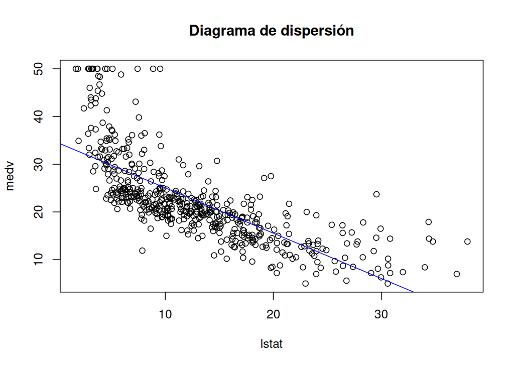

```r
lstat = Boston$lstat
medv = Boston$medv

modelo_lineal <- lm(medv~lstat)

plot(lstat, medv, main = "Diagrama de dispersión")
abline(modelo_lineal, col = "blue")
```

#### *e.* Realice la regresión lineal de medv utilizando todas las variables independientes. Determine los intervalos de confianza del 95% de los coeficientes asociados a las variables independientes.

##### La regresión lineal de medv utilizando todas las variables independientes es:

```r
#head(Boston)

crim = Boston$crim
zn = Boston$zn
indus = Boston$indus
chas = Boston$chas
nox = Boston$nox
rm = Boston$rm
age = Boston$age
dis = Boston$dis
rad = Boston$rad
tax = Boston$tax
ptratio = Boston$ptratio
black = Boston$black
lstat = Boston$lstat
medv = Boston$medv

regresion_medv <- lm(medv~crim + zn + indus + chas + nox + rm + age + dis + rad + tax + ptratio + black + lstat)

regresion_medv
```

```
##
## Call:
## lm(formula = medv ~ crim + zn + indus + chas + nox + rm + age +
##     dis + rad + tax + ptratio + black + lstat)
##
## Coefficients:
## (Intercept)         crim           zn        indus         chas          nox
##   3.646e+01   -1.080e-01    4.642e-02    2.056e-02    2.687e+00   -1.777e+01
##          rm          age          dis          rad          tax      ptratio
##   3.810e+00    6.922e-04   -1.476e+00    3.060e-01   -1.233e-02   -9.527e-01
##       black        lstat
##   9.312e-03   -5.248e-01
```

```r
summary(regresion_medv)
```

```
##
## Call:
## lm(formula = medv ~ crim + zn + indus + chas + nox + rm + age +
##     dis + rad + tax + ptratio + black + lstat)
##
## Residuals:
##     Min      1Q  Median      3Q     Max
## -15.595  -2.730  -0.518   1.777  26.199
##
## Coefficients:
##               Estimate Std. Error t value Pr(>|t|)
## (Intercept)  3.646e+01  5.103e+00   7.144 3.28e-12 ***
## crim        -1.080e-01  3.286e-02  -3.287 0.001087 **
## zn           4.642e-02  1.373e-02   3.382 0.000778 ***
## indus        2.056e-02  6.150e-02   0.334 0.738288
## chas         2.687e+00  8.616e-01   3.118 0.001925 **
## nox         -1.777e+01  3.820e+00  -4.651 4.25e-06 ***
## rm           3.810e+00  4.179e-01   9.116  < 2e-16 ***
## age          6.922e-04  1.321e-02   0.052 0.958229
## dis         -1.476e+00  1.995e-01  -7.398 6.01e-13 ***
## rad          3.060e-01  6.635e-02   4.613 5.07e-06 ***
## tax         -1.233e-02  3.760e-03  -3.280 0.001112 **
## ptratio     -9.527e-01  1.308e-01  -7.283 1.31e-12 ***
## black        9.312e-03  2.686e-03   3.467 0.000573 ***
## lstat       -5.248e-01  5.072e-02 -10.347  < 2e-16 ***
## ---
## Signif. codes:  0 '***' 0.001 '**' 0.01 '*' 0.05 '.' 0.1 ' ' 1
##
## Residual standard error: 4.745 on 492 degrees of freedom
## Multiple R-squared:  0.7406, Adjusted R-squared:  0.7338
## F-statistic: 108.1 on 13 and 492 DF,  p-value: < 2.2e-16
```

```r
# Variables significativas
var_signif <- c("(Intercept)", "crim", "zn", "chas", "nox", "rm", "dis", "rad", "tax", "ptratio", "black", "lstat")
```

##### Los intervalos de confianza del 95% de las variables significativas son:

```r
confint.lm(regresion_medv, parm = var_signif, level = 0.95)
```

```
##                     2.5 %        97.5 %
## (Intercept)  26.432226009  46.486750761
## crim         -0.172584412  -0.043438304
## zn            0.019448778   0.073392139
## chas          0.993904193   4.379563446
## nox         -25.271633564 -10.261588893
## rm            2.988726773   4.631003640
## dis          -1.867454981  -1.083678710
## rad           0.175692169   0.436406789
## tax          -0.019723286  -0.004945902
## ptratio      -1.209795296  -0.695699168
## black         0.004034306   0.014589060
## lstat        -0.624403622  -0.425113133
```

#### *f.* Con el modelo anterior (e) determine el intervalo de confianza del 95% del valor esperado de medv para el valor promedio de las variables independientes. Ahora, determine el intervalo de confianza del 95% para la predicción usando el mismo vector de entrada.

```r
# Valor promedio de las variables independientes
var_mean <- data.frame(crim = mean(crim), zn = mean(zn), indus = mean(indus), chas = mean(chas), nox = mean(nox), rm = mean(rm), age = mean(age), dis = mean(dis), rad = mean(rad), tax = mean(tax), ptratio = mean(ptratio), black = mean(black), lstat = mean(lstat))
```

##### Intervalo de confianza:

```r
predict(regresion_medv, var_mean, level=0.95, interval="confidence")
```

```
##        fit      lwr      upr
## 1 22.53281 22.11832 22.94729
```

##### Intervalo de confianza para la predicción:

```r
predict(regresion_medv, var_mean, level=0.95, interval="prediction")
```

```
##        fit      lwr      upr
## 1 22.53281 13.20005 31.86556
```

### *5.* Se realizan observaciones de dos respuestas sobre tres tratamientos…

**A) Hacer manova** Creando los datos :

Vector que corresponde al Tratamiento 1

```r
vector1 <- c(2,3,7,2,7)
vector2 <- c(9,2,5,1,5)
Tratamiento1 <- rbind(vector1,vector2)
Tratamiento1
```

```
##         [,1] [,2] [,3] [,4] [,5]
## vector1    2    3    7    2    7
## vector2    9    2    5    1    5
```

Vector que corresponde al Tratamiento 2

```r
vector3 <- c(3,2,9)
vector4 <- c(2,4,4)
Tratamiento2 <- rbind(vector3,vector4)
Tratamiento2
```

```
##         [,1] [,2] [,3]
## vector3    3    2    9
## vector4    2    4    4
```

Vector que corresponde al Tratamiento 3

```r
vector5 <- c(1,7,4,3)
vector6 <- c(4,2,9,2)
Tratamiento3 <- rbind(vector5,vector6)
Tratamiento3
```

```
##         [,1] [,2] [,3] [,4]
## vector5    1    7    4    3
## vector6    4    2    9    2
```

Xbarra_l N_l de los diferentes tratramientos

```r
n_1 <- 5 #N_l cuÃ¡ndo l = 1, es decir, n para el tratamiento 1
Xbarra_1 <- c(mean(vector1),mean(vector2)) #Xbarra_l cuando l = 1, es decir, El vector de medias para el tratamiento 1

n_2 <- 3  #N_l cuÃ¡ndo l = 2, es decir, n para el tratamiento 2
Xbarra_2 <- c(mean(vector3),mean(vector4))#Xbarra_l cuando l = 2, es decir, El vector de medias para el tratamiento 2

n_3<- 4  #N_l cuÃ¡ndo l = 3, es decir, n para el tratamiento 3
Xbarra_3 <- c(mean(vector5),mean(vector6))#Xbarra_l cuando l = 3, es decir, El vector de medias para el tratamiento 3
```

construyendo el Xbarra General & Otros valores importantes

```r
nGeneral <- n_1 + n_2 + n_3 #Refiere al n total, basicamente la suma de 1 a g = 3 de n_l

Xbarrag1 <- (sum(vector1) + sum(vector3) + sum(vector5) )/ nGeneral
Xbarrag2 <- (sum(vector2) + sum(vector4) + sum(vector6) )/ nGeneral

XbarraGeneral <- c(Xbarrag1,Xbarrag2) #Se saca la media manualmente dividiendo la sumatoria por el n general
XbarraGeneral
```

```
## [1] 4.166667 4.083333
```

```r
g <-3
p <-2
n<-c(n_1,n_2,n_3)# Vector con las medias de cada tratamiento
```

Obteniendo B:

```r
Xbarra <- c(Xbarra_1,Xbarra_2,Xbarra_3)


B <- (Xbarra_1 - XbarraGeneral) %*% t((Xbarra_1 - XbarraGeneral)) + (Xbarra_2 - XbarraGeneral) %*% t((Xbarra_2 - XbarraGeneral)) + (Xbarra_3 - XbarraGeneral) %*% t((Xbarra_3 - XbarraGeneral))
B
```

```
##            [,1]       [,2]
## [1,]  0.4247222 -0.4338889
## [2,] -0.4338889  0.6905556
```

Obteniendo W

```r
W <- 0
xjl <- 0
for (l in 1:g){
  for (j in 1:n[l]){
    if(l == 1){
      xjl <- c(vector1[j],vector2[j])
    }else if(l == 2){
      xjl <-c(vector3[j],vector4[j])

    }else if(l == 3){
      xjl <- c(vector5[j],vector6[j])
    }
    W <- ((xjl - Xbarra[l]) %*% t(xjl - Xbarra[l])) + W
  }
}

W
```

```
##           [,1]      [,2]
## [1,] 77.791111  3.857778
## [2,]  3.857778 78.924444
```

Obteniendo T

```r
T <- B + W
T
```

```
##           [,1]      [,2]
## [1,] 78.215833  3.423889
## [2,]  3.423889 79.615000
```

Obteniendo las Diferencias

```r
DiffB <- g-1
DiffB
```

```
## [1] 2
```

```r
DiffW <- nGeneral-g
DiffW
```

```
## [1] 9
```

```r
DiffT <- nGeneral-1
DiffT
```

```
## [1] 11
```

Construllendo la tabla manova

```r
"B"
```

```
## [1] "B"
```

```r
B
```

```
##            [,1]       [,2]
## [1,]  0.4247222 -0.4338889
## [2,] -0.4338889  0.6905556
```

```r
DiffB
```

```
## [1] 2
```

```r
"W"
```

```
## [1] "W"
```

```r
W
```

```
##           [,1]      [,2]
## [1,] 77.791111  3.857778
## [2,]  3.857778 78.924444
```

```r
DiffW
```

```
## [1] 9
```

```r
"T"
```

```
## [1] "T"
```

```r
T
```

```
##           [,1]      [,2]
## [1,] 78.215833  3.423889
## [2,]  3.423889 79.615000
```

```r
DiffT
```

```
## [1] 11
```

**B) Prueba de Hipótesis**

Para la prueba de hipotesis, se van aevaluar lo siguientes

Ho: T1=T2=T3 = 0 -> Los vectores de tratamiento son todos iguales a cero Ha: Ti =/= 0 para todo i -> Ninguno de los vectores de tratamiento es igual a cero

Lambda de Wilk

```r
normW <- sqrt(sum(W**2))
normW
```

```
## [1] 110.9517
```

```r
normB <- sqrt(sum(B**2))
normB
```

```
## [1] 1.016747
```

```r
lambda <- normW/normB
lambda
```

```
## [1] 109.1242
```

dado que p = 2 y g = 3 hacemos uso de la siguiente formula

```r
SDfMND <-((nGeneral - g - 1)/(g-1))  * ( (1 - sqrt(lambda))/lambda)  #Sampling distribution for multivariate normal data
SDfMND
```

```
## [1] -0.3462569
```

Sea alpha = 0.05

```r
Gdl <- c((2*(g-1)),(2*(nGeneral-g-1)))
Gdl
```

```
## [1]  4 16
```

```r
f <- 3.007
f
```

```
## [1] 3.007
```

**C) Prueba de hipotesis considerando muestra grande** Suponiendo que n (en este caso nGeneral) es grande, usamos la siguiente formula y revisamos si tiende a una chicuadrada

```r
s <- -log(lambda)*(nGeneral - 1 - ((2+g)/2))
s
```

```
## [1] -39.88614
```

```r
Gdl2 <- 2 *(g-1)
Gdl2
```

```
## [1] 4
```

```r
chicuadrada <- 9.4877
chicuadrada
```

```
## [1] 9.4877
```